# Group 5: Final project

Regression discontinuity

2024-05-10

## 0) Preparation

### a) Initial set-up

```r
# clear global environment
rm(list = ls())

# load packages
library(tidyverse)
library(knitr)
library(assertr)
library(kableExtra)
library(magrittr)
library(sandwich)
library(lmtest)
library(ivreg)

# suppress group_by messages throughout .rmd
options(dplyr.summarise.inform = FALSE)
# suppress scientific notation throughout .rmd
options(scipen = 100, digits = 4)
```

### b) Common functions

```r
# function to generate cross-tabulation
crosstab <- function(df,scroll=TRUE,...) {

  # anything specified after df will be treated as a var
  args <- quos(...)

  d<- df %>%
    # keep only vars specified
    select(!!!args) %>%
    # group by all combinations of variables
    group_by(!!!args) %>%
    # calculate n and percentages for each category
    mutate(N   = prettyNum(n(),big.mark=","),
           Pct = round((n() / nrow(.))*100,2)) %>%
    ungroup() %>%
    distinct() %>%
    verify(anyDuplicated(select(.,c(!!!args))) == 0) %>%
    arrange(!!!args) %>%
    # add table formatting
    kbl(full_width = T,
        align = "l") %>%
    kable_styling(bootstrap_options = c("striped","hover"))

  if (scroll == TRUE) { d %>% scroll_box(width = "100%", height = "600px") }
  else { d }

}
```

The goal of this project is to estimate the impact of schooling on earnings based on the introduction of compulsory schooling. Suppose that you are looking at a setting in which there was no compulsory schooling for individuals born prior to September 1, 1951, but for individuals born after September 1, 1951, a minimum school leaving age was introduced and set to age 16.

Please download `final_data_1.csv`. This dataset contains the following individual-level data (each row in the dataset corresponds to an individual):

- `birthyear`: individual’s year of birth (1947-1955)
- `birthmonth`: individual’s month of birth (1-12)
- `birthday`: individual’s day of birth (1-31)
- `lnearn45`: individual’s earnings measured at age 45
- `married45`: individual’s marital status measured at age 45
- `haskids45`: individual’s presence of children measured at age 45
- `s`: individual’s years of schooling completed
- `min_schl_age`: the minimum school leaving age that applied to the individual

## 1) Import & validate data

```r
# load RD data set
rd_dta <- read_csv("final_data_1.csv") %>%
          # confirm number of observations = 201,279
          verify(nrow(.) == 201279) %>%
          # confirm 8 variables
          verify(ncol(.) == 8) %>%
          # confirm identity of 8 variables
          verify(colnames(.) %in% c("min_schl_age","s","birthyear","birthday",
                                    "birthmonth","lnearn45","married45","haskids45")) %>%
          # check values of each variable
          verify(min_schl_age %in% c(0,16)) %>%
          verify(s %in% c(9,10,11,12,14,16,18)) %>%
          verify(birthyear %in% c(1947,1948,1949,1950,1951,1952,1953,1954,1955)) %>%
          verify(dplyr::between(birthday,1,31)) %>%
          verify(dplyr::between(birthmonth,1,12)) %>%
          verify(dplyr::between(lnearn45,9.38,13.39)) %>%
          verify(married45 %in% c(0,1)) %>%
          verify(haskids45 %in% c(0,1))
```

**X**: Whether student left school at or after age 16

**Y**: Earnings, marital status, having children

**Z**: Minimum school age requirement (i.e., was born on or after September 1, 1951).

**First stage:** X ~ Z

**Second stage:** Y ~ X_hat

*Inclusion condition: The instrument (minimum school age requirement) is a strong predictor of years of schooling (X). I.e., ideally t-statistic for the coefficient on Z in first-stage equation has an absolute value of 3 or higher.*

*Exclusion condition: Minimum school age policy must not directly affect earnings/marital status/parental status (i.e., dependent variables Y); the only effect minimum age policy should have on earnings/marital status/parental status is via the pathway through X (number of years of schooling). That is, minimum school leaving age policy must not be correlated with any factor in the error term in the second-stage equation (i.e., when Y is regressed on X and the other covariates).*

## 2) Construct student DOB

```r
rd_dta %<>%
  mutate(DOB = mdy(paste(birthmonth, birthday, birthyear, sep = "/")))

# validate 10 constructions
rd_dta %>% slice(0:10) %>% crosstab(.,scroll=F,DOB,birthyear,birthmonth,birthday)
```

| DOB | birthyear | birthmonth | birthday | N | Pct |
| --- | --- | --- | --- | --- | --- |
| 1948-07-29 | 1948 | 7 | 29 | 1 | 10 |
| 1949-11-16 | 1949 | 11 | 16 | 1 | 10 |
| 1950-08-27 | 1950 | 8 | 27 | 1 | 10 |
| 1950-12-28 | 1950 | 12 | 28 | 1 | 10 |
| 1952-09-22 | 1952 | 9 | 22 | 1 | 10 |
| 1952-11-23 | 1952 | 11 | 23 | 1 | 10 |
| 1953-04-15 | 1953 | 4 | 15 | 1 | 10 |
| 1953-11-20 | 1953 | 11 | 20 | 1 | 10 |
| 1955-01-12 | 1955 | 1 | 12 | 1 | 10 |
| 1955-11-18 | 1955 | 11 | 18 | 1 | 10 |

## 3) Construct policy introduction date

```r
rd_dta %<>%
  mutate(policy_date = mdy(paste("9", "1", "1951", sep = "/")))

# validate construction
rd_dta %>% crosstab(.,scroll=F,policy_date)
```

| policy_date | N | Pct |
| --- | --- | --- |
| 1951-09-01 | 201,279 | 100 |

## 4) Construct running variable

`runvar` = DOB relative to September 1, 1951

```r
rd_dta %<>%
  # generate runvar
  mutate(runvar = DOB - policy_date) %>%
  mutate(runvar = as.integer(runvar))

# validate 30 constructions
rd_dta %>% slice(0:30) %>% crosstab(.,scroll=T,runvar,DOB,policy_date)
```

| runvar | DOB | policy_date | N | Pct |
| --- | --- | --- | --- | --- |
| -1534 | 1947-06-20 | 1951-09-01 | 1 | 3.33 |
| -1133 | 1948-07-25 | 1951-09-01 | 1 | 3.33 |
| -1129 | 1948-07-29 | 1951-09-01 | 1 | 3.33 |
| -1000 | 1948-12-05 | 1951-09-01 | 1 | 3.33 |
| -776 | 1949-07-17 | 1951-09-01 | 1 | 3.33 |
| -712 | 1949-09-19 | 1951-09-01 | 1 | 3.33 |
| -654 | 1949-11-16 | 1951-09-01 | 1 | 3.33 |
| -370 | 1950-08-27 | 1951-09-01 | 1 | 3.33 |
| -247 | 1950-12-28 | 1951-09-01 | 1 | 3.33 |
| -8 | 1951-08-24 | 1951-09-01 | 1 | 3.33 |
| 42 | 1951-10-13 | 1951-09-01 | 1 | 3.33 |
| 112 | 1951-12-22 | 1951-09-01 | 1 | 3.33 |
| 346 | 1952-08-12 | 1951-09-01 | 1 | 3.33 |
| 387 | 1952-09-22 | 1951-09-01 | 1 | 3.33 |
| 449 | 1952-11-23 | 1951-09-01 | 1 | 3.33 |
| 454 | 1952-11-28 | 1951-09-01 | 1 | 3.33 |
| 524 | 1953-02-06 | 1951-09-01 | 1 | 3.33 |
| 592 | 1953-04-15 | 1951-09-01 | 1 | 3.33 |
| 730 | 1953-08-31 | 1951-09-01 | 1 | 3.33 |
| 761 | 1953-10-01 | 1951-09-01 | 1 | 3.33 |
| 811 | 1953-11-20 | 1951-09-01 | 1 | 3.33 |
| 823 | 1953-12-02 | 1951-09-01 | 2 | 6.67 |
| 851 | 1953-12-30 | 1951-09-01 | 1 | 3.33 |
| 1201 | 1954-12-15 | 1951-09-01 | 1 | 3.33 |
| 1229 | 1955-01-12 | 1951-09-01 | 1 | 3.33 |
| 1247 | 1955-01-30 | 1951-09-01 | 1 | 3.33 |
| 1254 | 1955-02-06 | 1951-09-01 | 1 | 3.33 |
| 1539 | 1955-11-18 | 1951-09-01 | 1 | 3.33 |
| 1560 | 1955-12-09 | 1951-09-01 | 1 | 3.33 |

## 5) Create binned running variable

Divide running variable into 90-day bins.

```r
rd_dta %<>%
  # generate binned version of runvar
  # (bin size = 90 days -- students born on 9/1/51 to 89 days after will be in bin 0
  mutate(runvarbin_90day = floor(runvar / 90))

# validate construction of runvarbin_90day variable (check first 5 observations with each bin)
rd_dta %>% group_by(runvarbin_90day) %>% slice(0:5) %>% crosstab(.,scroll=T,runvarbin_90day,runvar)
```

| runvarbin_90day | runvar | N | Pct |
| --- | --- | --- | --- |
| -19 | -1699 | 1 | 0.54 |
| -19 | -1677 | 1 | 0.54 |
| -19 | -1676 | 1 | 0.54 |
| -19 | -1656 | 1 | 0.54 |
| -19 | -1624 | 1 | 0.54 |
| -18 | -1617 | 1 | 0.54 |
| -18 | -1592 | 1 | 0.54 |
| -18 | -1588 | 1 | 0.54 |
| -18 | -1578 | 1 | 0.54 |
| -18 | -1534 | 1 | 0.54 |
| -17 | -1527 | 1 | 0.54 |
| -17 | -1478 | 1 | 0.54 |
| -17 | -1468 | 2 | 1.08 |
| -17 | -1461 | 1 | 0.54 |
| -16 | -1423 | 1 | 0.54 |
| -16 | -1405 | 1 | 0.54 |
| -16 | -1401 | 1 | 0.54 |
| -16 | -1397 | 1 | 0.54 |
| -16 | -1358 | 1 | 0.54 |
| -15 | -1303 | 1 | 0.54 |
| -15 | -1289 | 1 | 0.54 |
| -15 | -1287 | 1 | 0.54 |
| -15 | -1269 | 1 | 0.54 |
| -15 | -1266 | 1 | 0.54 |
| -14 | -1257 | 1 | 0.54 |
| -14 | -1211 | 1 | 0.54 |
| -14 | -1208 | 1 | 0.54 |
| -14 | -1202 | 1 | 0.54 |
| -14 | -1182 | 1 | 0.54 |
| -13 | -1168 | 1 | 0.54 |

[output cut: 149 more lines]

```r
# examine size of bins
crosstab(rd_dta,scroll=T,runvarbin_90day)
```

| runvarbin_90day | N | Pct |
| --- | --- | --- |
| -19 | 5,137 | 2.55 |
| -18 | 5,390 | 2.68 |
| -17 | 5,482 | 2.72 |
| -16 | 5,569 | 2.77 |
| -15 | 5,534 | 2.75 |
| -14 | 5,471 | 2.72 |
| -13 | 5,543 | 2.75 |
| -12 | 5,507 | 2.74 |
| -11 | 5,522 | 2.74 |
| -10 | 5,592 | 2.78 |
| -9 | 5,539 | 2.75 |
| -8 | 5,557 | 2.76 |
| -7 | 5,549 | 2.76 |
| -6 | 5,500 | 2.73 |
| -5 | 5,415 | 2.69 |
| -4 | 5,490 | 2.73 |
| -3 | 5,462 | 2.71 |
| -2 | 5,531 | 2.75 |
| -1 | 5,364 | 2.66 |
| 0 | 5,608 | 2.79 |
| 1 | 5,690 | 2.83 |
| 2 | 5,476 | 2.72 |
| 3 | 5,500 | 2.73 |
| 4 | 5,409 | 2.69 |
| 5 | 5,677 | 2.82 |
| 6 | 5,652 | 2.81 |
| 7 | 5,421 | 2.69 |
| 8 | 5,439 | 2.70 |
| 9 | 5,481 | 2.72 |
| 10 | 5,604 | 2.78 |
| 11 | 5,571 | 2.77 |
| 12 | 5,430 | 2.70 |
| 13 | 5,524 | 2.74 |
| 14 | 5,503 | 2.73 |
| 15 | 5,524 | 2.74 |
| 16 | 5,535 | 2.75 |
| 17 | 3,081 | 1.53 |

## 6) Validate `min_schl_age`

Confirm `min_schl_age` = 16 if and only if student born on or after September 1, 1951; = 0 otherwise.

```r
rd_dta %<>%
  # create binary to indicate whether DOB on or after policy implementation date
  mutate(subject_to_policy = ifelse(runvar >= 0,1,0))

# validate construction (first 50 within each value of subject_to_policy)
rd_dta %>% group_by(subject_to_policy) %>% slice(0:50) %>% crosstab(.,scroll=T,subject_to_policy,runvar)
```

| subject_to_policy | runvar | N | Pct |
| --- | --- | --- | --- |
| 0 | -1699 | 1 | 1 |
| 0 | -1677 | 1 | 1 |
| 0 | -1676 | 1 | 1 |
| 0 | -1656 | 1 | 1 |
| 0 | -1624 | 1 | 1 |
| 0 | -1617 | 1 | 1 |
| 0 | -1592 | 1 | 1 |
| 0 | -1588 | 1 | 1 |
| 0 | -1578 | 1 | 1 |
| 0 | -1562 | 1 | 1 |
| 0 | -1534 | 1 | 1 |
| 0 | -1527 | 1 | 1 |
| 0 | -1468 | 1 | 1 |
| 0 | -1461 | 1 | 1 |
| 0 | -1397 | 1 | 1 |
| 0 | -1303 | 1 | 1 |
| 0 | -1289 | 1 | 1 |
| 0 | -1257 | 1 | 1 |
| 0 | -1208 | 1 | 1 |
| 0 | -1168 | 1 | 1 |
| 0 | -1133 | 1 | 1 |
| 0 | -1129 | 1 | 1 |
| 0 | -1123 | 1 | 1 |
| 0 | -1122 | 1 | 1 |
| 0 | -1096 | 1 | 1 |
| 0 | -1021 | 1 | 1 |
| 0 | -1000 | 1 | 1 |
| 0 | -931 | 1 | 1 |
| 0 | -914 | 1 | 1 |
| 0 | -858 | 1 | 1 |

[output cut: 67 more lines]

```r
# confirm this variable maps 1:1 to min_schl_age
crosstab(rd_dta,scroll=F,subject_to_policy,min_schl_age)
```

| subject_to_policy | min_schl_age | N | Pct |
| --- | --- | --- | --- |
| 0 | 0 | 104,154 | 51.75 |
| 1 | 16 | 97,125 | 48.25 |

## 7) Create schooling binary

Create `left_sch_age16_or_later` = 1 if student left school in the 11th grade or later.

```r
rd_dta %<>%
  # create binary to indicate whether student actually left school in 11th grade or later
  mutate(left_sch_age16_or_later = ifelse(s >= 11,1,0))

# validate construction
crosstab(rd_dta,scroll=F,left_sch_age16_or_later,s)
```

| left_sch_age16_or_later | s | N | Pct |
| --- | --- | --- | --- |
| 0 | 9 | 5,251 | 2.61 |
| 0 | 10 | 8,410 | 4.18 |
| 1 | 11 | 22,570 | 11.21 |
| 1 | 12 | 88,397 | 43.92 |
| 1 | 14 | 23,930 | 11.89 |
| 1 | 16 | 36,650 | 18.21 |
| 1 | 18 | 16,071 | 7.98 |

## 8) First stage

Estimate $LeftSchAge16OrLater_i = \alpha_0 + \alpha_1runvar_i + \beta_1SubjectToPolicy_i + \alpha_2(runvar_i*SubjectToPolicy_i) + \epsilon_i$

```r
# run first-stage regression, instrumenting whether they actually attended school until age 16
# using whether they were subject to the minimum schooling policy
rdfs_lm1 = lm(left_sch_age16_or_later ~ runvar + subject_to_policy + I(subject_to_policy * runvar), data = rd_dta)

summary(rdfs_lm1)
```

```
##
## Call:
## lm(formula = left_sch_age16_or_later ~ runvar + subject_to_policy +
##     I(subject_to_policy * runvar), data = rd_dta)
##
## Residuals:
##    Min     1Q Median     3Q    Max
## -0.869  0.000  0.000  0.131  0.132
##
## Coefficients:
##                                   Estimate   Std. Error t value
## (Intercept)                    0.869285271  0.001510076  575.66
## runvar                         0.000000524  0.000001534    0.34
## subject_to_policy              0.130714729  0.002166494   60.33
## I(subject_to_policy * runvar) -0.000000524  0.000002294   -0.23
##                                          Pr(>|t|)
## (Intercept)                   <0.0000000000000002 ***
## runvar                                       0.73
## subject_to_policy             <0.0000000000000002 ***
## I(subject_to_policy * runvar)                0.82
## ---
## Signif. codes:  0 '***' 0.001 '**' 0.01 '*' 0.05 '.' 0.1 ' ' 1
##
## Residual standard error: 0.243 on 201275 degrees of freedom
## Multiple R-squared:  0.0679, Adjusted R-squared:  0.0679
## F-statistic: 4.89e+03 on 3 and 201275 DF,  p-value: <0.0000000000000002
```

Students that were subject to the policy were 13.1% more likely to leave school at age 16 or higher than students not subject to policy (i.e., coefficient on `subject_to_policy`). Massive t-statistic.

```r
# run first-stage regression, instrumenting number of years of school attended
# using whether they were subject to the minimum schooling policy
rdfs_lm2 = lm(s ~ runvar + subject_to_policy + I(subject_to_policy * runvar), data = rd_dta)

summary(rdfs_lm2)
```

```
##
## Call:
## lm(formula = s ~ runvar + subject_to_policy + I(subject_to_policy *
##     runvar), data = rd_dta)
##
## Residuals:
##    Min     1Q Median     3Q    Max
##  -4.07  -1.29  -1.07   2.70   4.93
##
## Coefficients:
##                                   Estimate   Std. Error t value
## (Intercept)                   13.068417584  0.014442631  904.85
## runvar                         0.000000573  0.000014674    0.04
## subject_to_policy              0.190122089  0.020720728    9.18
## I(subject_to_policy * runvar)  0.000029191  0.000021939    1.33
##                                          Pr(>|t|)
## (Intercept)                   <0.0000000000000002 ***
## runvar                                       0.97
## subject_to_policy             <0.0000000000000002 ***
## I(subject_to_policy * runvar)                0.18
## ---
## Signif. codes:  0 '***' 0.001 '**' 0.01 '*' 0.05 '.' 0.1 ' ' 1
##
## Residual standard error: 2.32 on 201275 degrees of freedom
## Multiple R-squared:  0.00213,    Adjusted R-squared:  0.00212
## F-statistic:  143 on 3 and 201275 DF,  p-value: <0.0000000000000002
```

## 9) First stage plots

Plot whether student was born on or after September 1, 1951 (i.e., treated) against running variable (birthdate relative to policy taking effect)

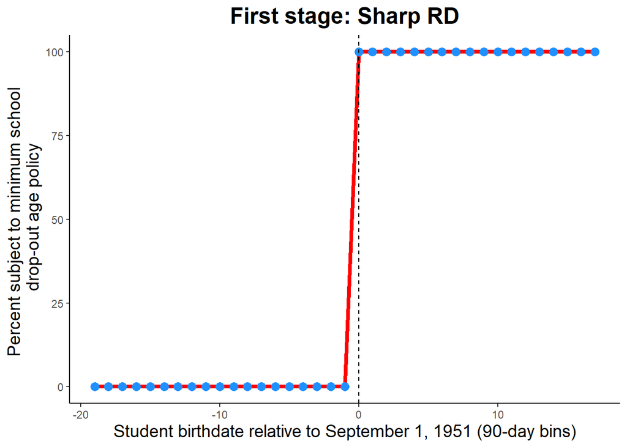

```r
plot_fs <- function(df,
                    sharp = TRUE,
                    binned_run_var,
                    treat_var,
                    xlab,
                    ylab) {

  if (sharp == TRUE) { type <- "Sharp" }
  else               { type <- "Fuzzy" }

  plot_dta <- df %>%
              group_by(!!sym(binned_run_var)) %>%
              summarise(mean_treat = mean(!!sym(treat_var)) * 100)

  ggplot(plot_dta, aes(x = !!sym(binned_run_var), y = mean_treat)) +
         # add connecting line
         geom_line(color='red', size=1.5) +
         # add data points
         geom_point(size = 3, color = "dodgerblue") +
         expand_limits(y = 0) +
         # add labels
         labs(y = ylab,
              x = xlab) +
         geom_vline(xintercept = 0, lty=2) +
         # add title
         ggtitle(paste0("First stage: ",type," RD")) +
         # add formatting
         theme(panel.grid.major = element_blank(),
               panel.grid.minor = element_blank(),
               panel.background = element_blank(),
               axis.line = element_line(colour = "black"),
               plot.title = element_text(size = 18, face = "bold", hjust = 0.5),
               axis.title = element_text(size = 14))


}

# Sharp RD
plot_fs(df = rd_dta,
        sharp = TRUE,
        binned_run_var = "runvarbin_90day",
        treat_var = "subject_to_policy",
        xlab = "Student birthdate relative to September 1, 1951 (90-day bins)",
        ylab = "Percent subject to minimum school \n drop-out age policy")
```

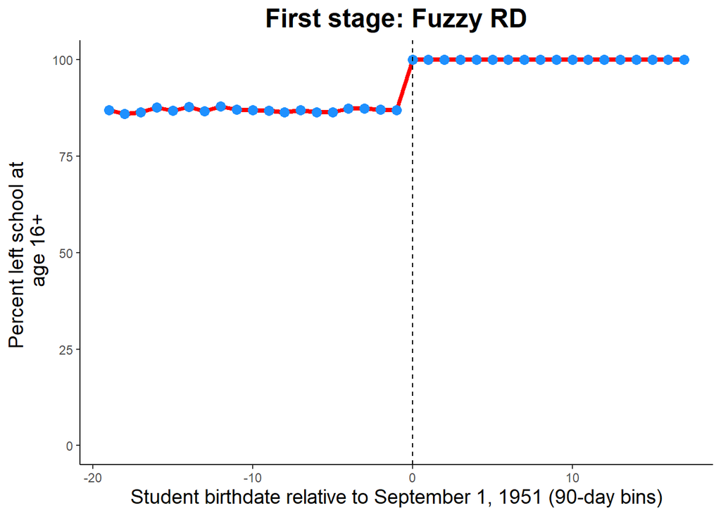

```r
# Fuzzy RD
plot_fs(df = rd_dta,
        sharp = FALSE,
        binned_run_var = "runvarbin_90day",
        treat_var = "left_sch_age16_or_later",
        xlab = "Student birthdate relative to September 1, 1951 (90-day bins)",
        ylab = "Percent left school at \n age 16+")
```

## 10) First-stage permutation test

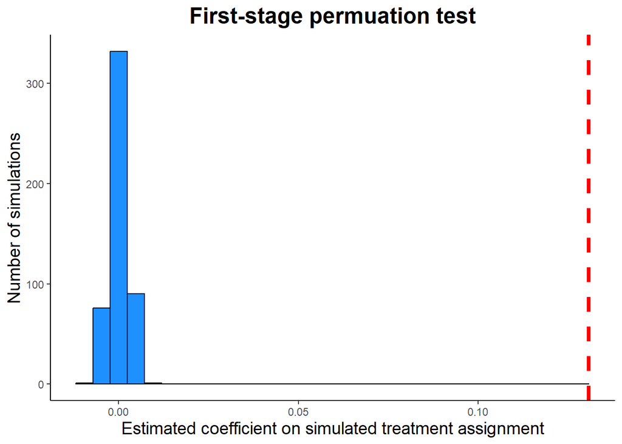

```r
stopifnot(min(rd_dta$runvar) == -1704)
stopifnot(max(rd_dta$runvar) == 1582)

plot_permutation_test_fs <- function(df,
                                     x_var,
                                     z_var,
                                     run_var,
                                     n_simulations) {

  # run real first stage regression
  rdfs_lm = lm(get(x_var) ~ get(run_var) + get(z_var) + I(get(z_var) * get(run_var)), data = df)

  # store estimate on z
  z_est_fs = coefficients(rdfs_lm)[3]

  # initialize empty data frame for first stage results
  coefs <- tibble(estimate_fs = numeric())

  plot_dta <- df %>%
              mutate(x = get(x_var))

  for(ii in 1:n_simulations) {

    # randomly assign distance relative to policy start date and use this to reconstruct instrument (whether student is subject to policy)
    plot_dta %<>%
      mutate(new_runvar = sample(-1704:1582,nrow(.),replace=TRUE)) %>%
      mutate(had_policy = ifelse(new_runvar >= 0,1,0))

    # run first stage with random instrument
    reg_fs = lm(x ~ new_runvar + had_policy + I(had_policy * new_runvar), data = plot_dta)

    # store estimates on Z
    coefs <- coefs %>%
             add_row(estimate_fs = coefficients(reg_fs)['had_policy'])

  }

  # plot first-stage permutation test results
  ggplot(coefs, mapping = aes(estimate_fs)) +
    geom_histogram(color = 'black', fill = 'dodgerblue') +
    labs(y = "Number of simulations",
         x = "Estimated coefficient on simulated treatment assignment") +
    # plot true estimate
    geom_vline(xintercept = z_est_fs, lty=2, size = 1.5, color = 'red') +
         # add title
         ggtitle(paste0("First-stage permuation test")) +
         # add formatting
         theme(panel.grid.major = element_blank(),
               panel.grid.minor = element_blank(),
               panel.background = element_blank(),
               axis.line = element_line(colour = "black"),
               plot.title = element_text(size = 18, face = "bold", hjust = 0.5),
               axis.title = element_text(size = 14))

}

# FS permutation test
plot_permutation_test_fs(df = rd_dta,
                         x_var = "left_sch_age16_or_later",
                         z_var = "subject_to_policy",
                         run_var = "runvar",
                         n_simulations = 500)
```

## 11) Frequency plots

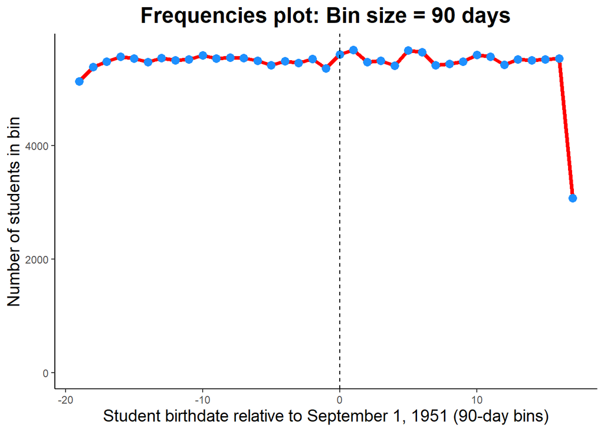

```r
plot_frequencies <- function(df,
                             binned_run_var,
                             xlab,
                             bin_size) {

  plot_dta <- df %>%
              group_by(!!sym(binned_run_var)) %>%
              summarise(n = n())

  ggplot(plot_dta, aes(x = !!sym(binned_run_var), y = n)) +
         # add connecting line
         geom_line(color='red', size=1.5) +
         expand_limits(y = 0) +
         # add data points
         geom_point(size = 3, color = "dodgerblue") +
         # add labels
         labs(y = "Number of students in bin",
              x = xlab) +
         geom_vline(xintercept = 0, lty=2) +
         # add title
         ggtitle(paste0("Frequencies plot: Bin size = ",bin_size," days")) +
         # add formatting
         theme(panel.grid.major = element_blank(),
               panel.grid.minor = element_blank(),
               panel.background = element_blank(),
               axis.line = element_line(colour = "black"),
               plot.title = element_text(size = 18, face = "bold", hjust = 0.5),
               axis.title = element_text(size = 14))


}

# Sharp RD
plot_frequencies(df = rd_dta,
                 binned_run_var = "runvarbin_90day",
                 xlab = "Student birthdate relative to September 1, 1951 (90-day bins)",
                 bin_size = 90)
```

## 12) Estimating RD via IV

### Earnings

Instrument for whether student left school at age 16+ with whether they were subject to a minimum drop-out age policy.

```r
rd_iv_earnings = ivreg(lnearn45 ~ runvar |                                       # exogenous regressors
                                  left_sch_age16_or_later +                      # endogenous regressors
                                  I(left_sch_age16_or_later * runvar) |
                                  subject_to_policy +                            # instrumental variables
                                  I(subject_to_policy * runvar), data = rd_dta)

summary(rd_iv_earnings)
```

```
##
## Call:
## ivreg(formula = lnearn45 ~ runvar | left_sch_age16_or_later +
##     I(left_sch_age16_or_later * runvar) | subject_to_policy +
##     I(subject_to_policy * runvar), data = rd_dta)
##
## Residuals:
##      Min       1Q   Median       3Q      Max
## -2.27358 -0.42038  0.00684  0.43256  1.85164
##
## Coefficients:
##                                       Estimate Std. Error t value
## (Intercept)                         10.9394943  0.0371873  294.17
## left_sch_age16_or_later              0.1335516  0.0397821    3.36
## I(left_sch_age16_or_later * runvar)  0.0009451  0.0000417   22.68
## runvar                              -0.0006127  0.0000387  -15.82
##                                                 Pr(>|t|)
## (Intercept)                         < 0.0000000000000002 ***
## left_sch_age16_or_later                          0.00079 ***
## I(left_sch_age16_or_later * runvar) < 0.0000000000000002 ***
## runvar                              < 0.0000000000000002 ***
##
## Diagnostic tests:
##                                                           df1    df2 statistic
## Weak instruments (left_sch_age16_or_later)                  2 201275      1825
## Weak instruments (I(left_sch_age16_or_later * runvar))      2 201275      1714
## Wu-Hausman                                                  2 201273       280
## Sargan                                                      0     NA        NA
##                                                                    p-value
## Weak instruments (left_sch_age16_or_later)             <0.0000000000000002 ***
## Weak instruments (I(left_sch_age16_or_later * runvar)) <0.0000000000000002 ***
## Wu-Hausman                                             <0.0000000000000002 ***
## Sargan                                                                  NA
## ---
## Signif. codes:  0 '***' 0.001 '**' 0.01 '*' 0.05 '.' 0.1 ' ' 1
##
## Residual standard error: 0.583 on 201275 degrees of freedom
## Multiple R-Squared: 0.0749,  Adjusted R-squared: 0.0749
## Wald test: 1.36e+04 on 3 and 201275 DF,  p-value: <0.0000000000000002
```

### Married

```r
rd_iv_married = ivreg(married45 ~ runvar |                                       # exogenous regressors
                                  left_sch_age16_or_later +                      # endogenous regressors
                                  I(left_sch_age16_or_later * runvar) |
                                  subject_to_policy +                            # instrumental variables
                                  I(subject_to_policy * runvar), data = rd_dta)

summary(rd_iv_married)
```

```
##
## Call:
## ivreg(formula = married45 ~ runvar | left_sch_age16_or_later +
##     I(left_sch_age16_or_later * runvar) | subject_to_policy +
##     I(subject_to_policy * runvar), data = rd_dta)
##
## Residuals:
##    Min     1Q Median     3Q    Max
## -0.419 -0.415 -0.410  0.585  0.740
##
## Coefficients:
##                                       Estimate Std. Error t value
## (Intercept)                          0.2598050  0.0311468    8.34
## left_sch_age16_or_later              0.1543565  0.0333201    4.63
## I(left_sch_age16_or_later * runvar)  0.0000281  0.0000349    0.81
## runvar                              -0.0000251  0.0000324   -0.77
##                                                 Pr(>|t|)
## (Intercept)                         < 0.0000000000000002 ***
## left_sch_age16_or_later                        0.0000036 ***
## I(left_sch_age16_or_later * runvar)                 0.42
## runvar                                              0.44
##
## Diagnostic tests:
##                                                           df1    df2 statistic
## Weak instruments (left_sch_age16_or_later)                  2 201275   1825.30
## Weak instruments (I(left_sch_age16_or_later * runvar))      2 201275   1714.19
## Wu-Hausman                                                  2 201273      4.13
## Sargan                                                      0     NA        NA
##                                                                    p-value
## Weak instruments (left_sch_age16_or_later)             <0.0000000000000002 ***
## Weak instruments (I(left_sch_age16_or_later * runvar)) <0.0000000000000002 ***
## Wu-Hausman                                                           0.016 *
## Sargan                                                                  NA
## ---
## Signif. codes:  0 '***' 0.001 '**' 0.01 '*' 0.05 '.' 0.1 ' ' 1
##
## Residual standard error: 0.488 on 201275 degrees of freedom
## Multiple R-Squared: 0.0117,  Adjusted R-squared: 0.0117
## Wald test: 34.6 on 3 and 201275 DF,  p-value: <0.0000000000000002
```

### Has kids

```r
rd_iv_haskids = ivreg(haskids45 ~ runvar |                                       # exogenous regressors
                                  left_sch_age16_or_later +                      # endogenous regressors
                                  I(left_sch_age16_or_later * runvar) |
                                  subject_to_policy +                            # instrumental variables
                                  I(subject_to_policy * runvar), data = rd_dta)

summary(rd_iv_haskids)
```

```
##
## Call:
## ivreg(formula = haskids45 ~ runvar | left_sch_age16_or_later +
##     I(left_sch_age16_or_later * runvar) | subject_to_policy +
##     I(subject_to_policy * runvar), data = rd_dta)
##
## Residuals:
##    Min     1Q Median     3Q    Max
## -0.682 -0.676  0.320  0.322  0.585
##
## Coefficients:
##                                       Estimate Std. Error t value
## (Intercept)                          0.4848990  0.0297866   16.28
## left_sch_age16_or_later              0.1937781  0.0318650    6.08
## I(left_sch_age16_or_later * runvar) -0.0000432  0.0000334   -1.29
## runvar                               0.0000411  0.0000310    1.32
##                                                 Pr(>|t|)
## (Intercept)                         < 0.0000000000000002 ***
## left_sch_age16_or_later                     0.0000000012 ***
## I(left_sch_age16_or_later * runvar)                 0.20
## runvar                                              0.19
##
## Diagnostic tests:
##                                                           df1    df2 statistic
## Weak instruments (left_sch_age16_or_later)                  2 201275   1825.30
## Weak instruments (I(left_sch_age16_or_later * runvar))      2 201275   1714.19
## Wu-Hausman                                                  2 201273      7.03
## Sargan                                                      0     NA        NA
##                                                                     p-value
## Weak instruments (left_sch_age16_or_later)             < 0.0000000000000002 ***
## Weak instruments (I(left_sch_age16_or_later * runvar)) < 0.0000000000000002 ***
## Wu-Hausman                                                          0.00088 ***
## Sargan                                                                   NA
## ---
## Signif. codes:  0 '***' 0.001 '**' 0.01 '*' 0.05 '.' 0.1 ' ' 1
##
## Residual standard error: 0.467 on 201275 degrees of freedom
## Multiple R-Squared: 0.0248,  Adjusted R-squared: 0.0248
## Wald test: 56.1 on 3 and 201275 DF,  p-value: <0.0000000000000002
```

## 13) Reduced form plots

```r
plot_rf <- function(df,
                    binned_run_var,
                    y_var,
                    xlab,
                    ylab,
                    ymin,
                    ymax) {

  plot_dta <- df %>%
              group_by(!!sym(binned_run_var)) %>%
              summarise(mean_y = mean(!!sym(y_var)))

  if (y_var %in% c("married45","haskids45")) {plot_dta %<>% mutate(mean_y = mean_y * 100)}

  ggplot(plot_dta, aes(x = !!sym(binned_run_var), y = mean_y)) +
         # add connecting line
         geom_line(color='red', size=1.5) +
         # add data points
         geom_point(size = 3, color = "dodgerblue") +
         # add labels
         labs(y = ylab,
              x = xlab) +
         #expand_limits(y = 0) +
         scale_y_continuous(limits = c(ymin, ymax)) +
         geom_vline(xintercept = 0, lty=2) +
         # add title
         ggtitle(paste0("Reduced form: ",ylab)) +
         # add formatting
         theme(panel.grid.major = element_blank(),
               panel.grid.minor = element_blank(),
               panel.background = element_blank(),
               axis.line = element_line(colour = "black"),
               plot.title = element_text(size = 18, face = "bold", hjust = 0.5),
               axis.title = element_text(size = 14))


}
```

### Earnings

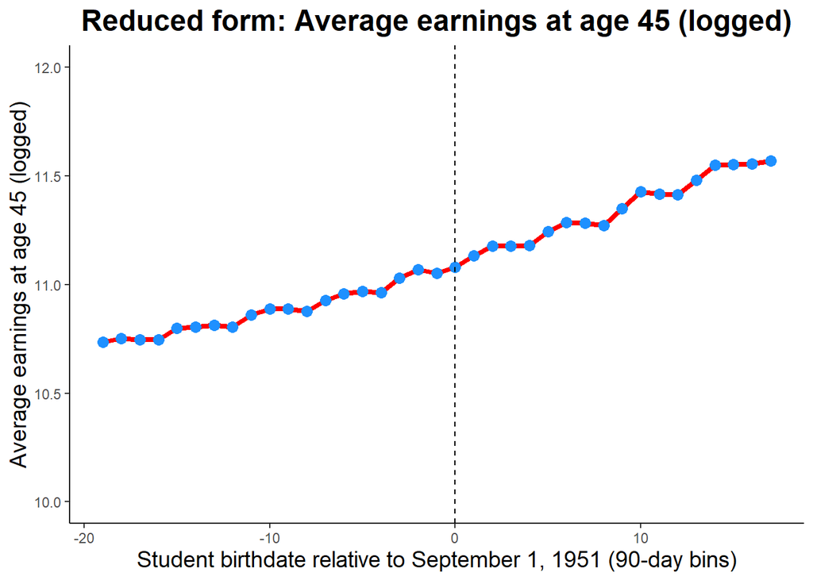

```r
# Reduced form plot for earnings
plot_rf(df = rd_dta,
        binned_run_var = "runvarbin_90day",
        y_var = "lnearn45",
        xlab = "Student birthdate relative to September 1, 1951 (90-day bins)",
        ylab = "Average earnings at age 45 (logged)",
        ymin = 10,
        ymax = 12)
```

### Married

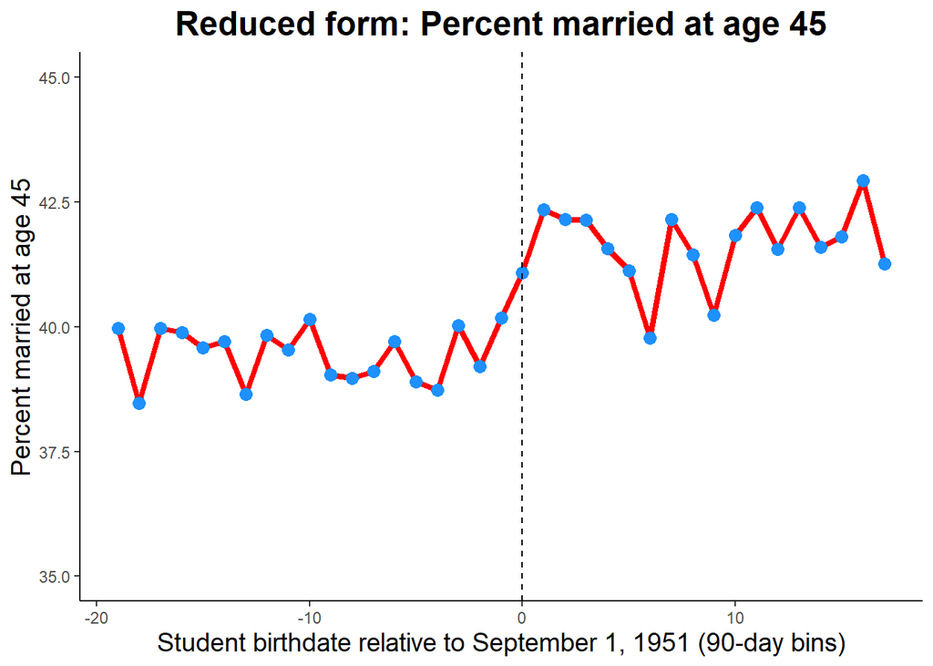

```r
plot_rf(df = rd_dta,
        binned_run_var = "runvarbin_90day",
        y_var = "married45",
        xlab = "Student birthdate relative to September 1, 1951 (90-day bins)",
        ylab = "Percent married at age 45",
        ymin = 35,
        ymax = 45)
```

### Has kids

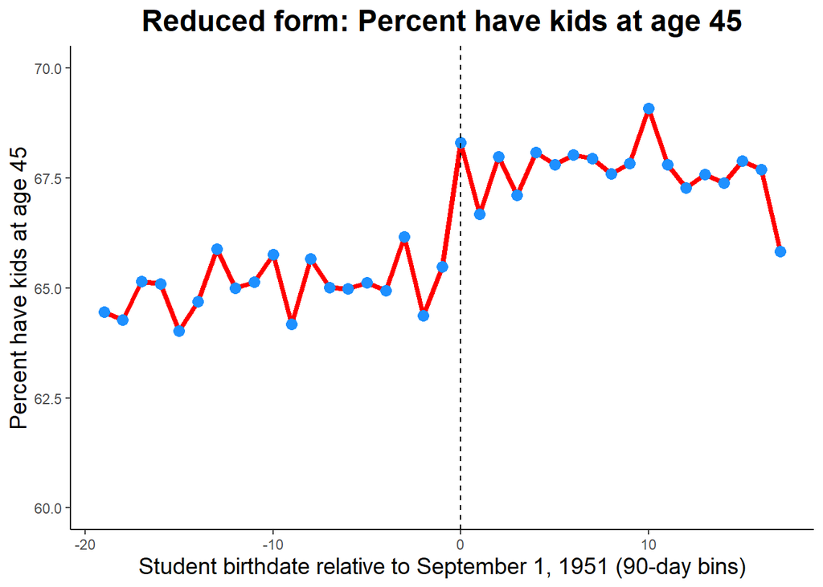

```r
plot_rf(df = rd_dta,
        binned_run_var = "runvarbin_90day",
        y_var = "haskids45",
        xlab = "Student birthdate relative to September 1, 1951 (90-day bins)",
        ylab = "Percent have kids at age 45",
        ymin = 60,
        ymax = 70)
```

## 14) Reduced form permutation test

```r
plot_permutation_test_rf <- function(df,
                                     y_var,
                                     z_var,
                                     run_var,
                                     y_var_text,
                                     n_simulations) {

  # run real reduced form regression
  rdrf_lm = lm(get(y_var) ~ get(run_var) + get(z_var) + I(get(z_var) * get(run_var)), data = df)

  # store estimate on z
  z_est_rf = coefficients(rdrf_lm)[3]

  # initialize empty data frame for first stage and reduced form permutation test results
  coefs <- tibble(estimate_rf = numeric())

  plot_dta <- df %>%
              mutate(y = get(y_var))

  for(ii in 1:n_simulations) {

    # randomly assign distance relative to policy start date and use this to reconstruct instrument (whether student is subject to policy)
    plot_dta %<>%
      mutate(new_runvar = sample(-1704:1582,nrow(.),replace=TRUE)) %>%
      mutate(had_policy = ifelse(new_runvar >= 0,1,0))

    # run reduced form with random instrument
    reg_rf = lm(y ~ new_runvar + had_policy + I(had_policy * new_runvar), data = plot_dta)

    # store estimates on Z
    coefs <- coefs %>%
             add_row(estimate_rf = coefficients(reg_rf)['had_policy'])

  }

  # plot reduced form permutation test results
  ggplot(coefs, mapping = aes(estimate_rf)) +
    geom_histogram(color = 'black', fill = 'dodgerblue') +
    labs(y = "Number of simulations",
         x = "Estimated coefficient on simulated treatment assignment") +
    # plot true estimate
    geom_vline(xintercept = z_est_rf, lty=2,color='red',size=1.5) +
         # add title
         ggtitle(paste0("Reduced form permuation test (outcome = ",y_var_text,")")) +
         # add formatting
         theme(panel.grid.major = element_blank(),
               panel.grid.minor = element_blank(),
               panel.background = element_blank(),
               axis.line = element_line(colour = "black"),
               plot.title = element_text(size = 18, face = "bold", hjust = 0.5),
               axis.title = element_text(size = 14))

}
```

### Earnings

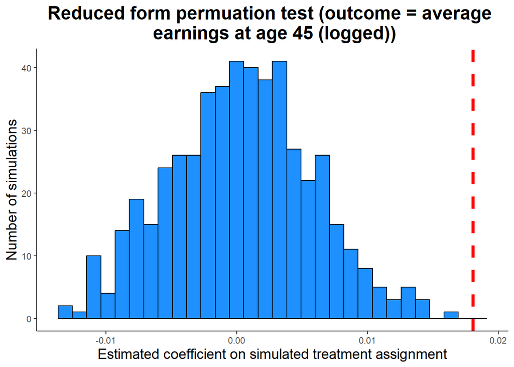

```r
plot_permutation_test_rf(df = rd_dta,
                      y_var = "lnearn45",
                      z_var = "subject_to_policy",
                      run_var = "runvar",
                      y_var_text = "average \n earnings at age 45 (logged)",
                      n_simulations = 500)
```

### Married

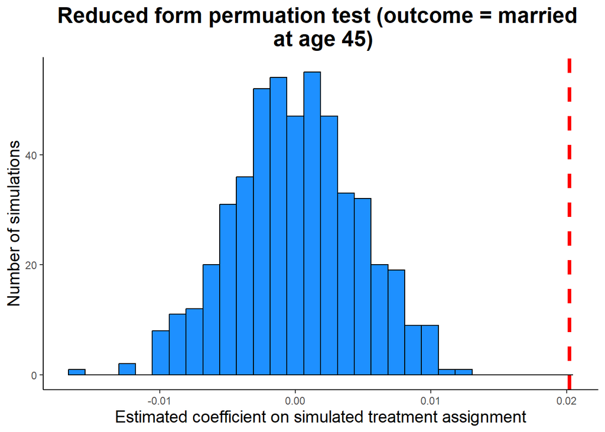

```r
plot_permutation_test_rf(df = rd_dta,
                      y_var = "married45",
                      z_var = "subject_to_policy",
                      run_var = "runvar",
                      y_var_text = "married \n at age 45",
                      n_simulations = 500)
```

### Has kids

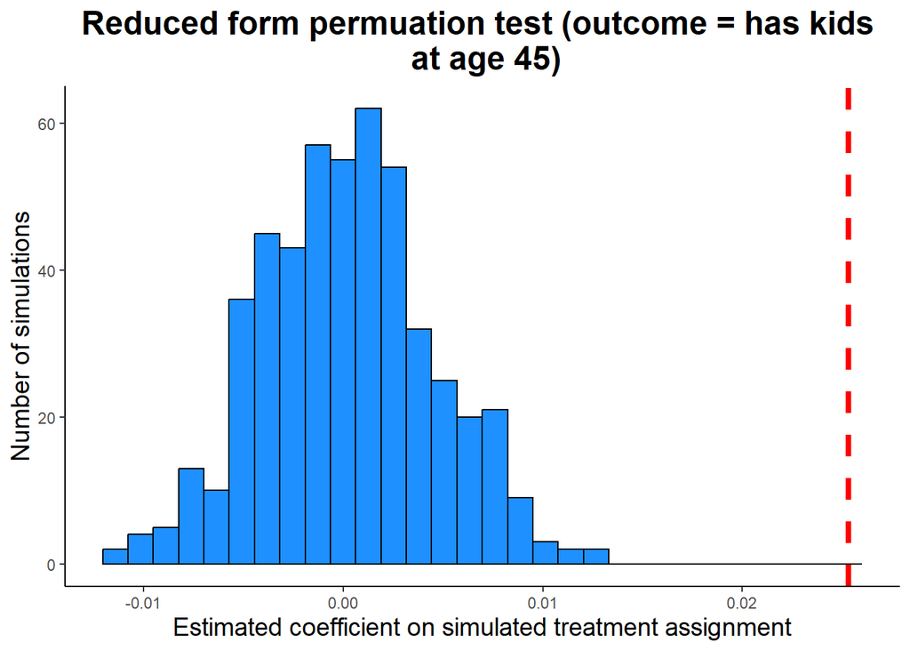

```r
plot_permutation_test_rf(df = rd_dta,
                      y_var = "haskids45",
                      z_var = "subject_to_policy",
                      run_var = "runvar",
                      y_var_text = "has kids \n at age 45",
                      n_simulations = 500)
```